# 二元配置分散分析

## 課題3

この表は、あるレストランで４つのフライドチキンの試作品を作り６０人の人に試食してもらったスコアデータである。

・普通味で普通の衣 ・辛口でクリスピー の２種類にメニューに絞った方が良い（普通味のクリスピーチキンや普通の衣の辛口はやめる）ことを2-way ANOVAを用いて示しなさい。

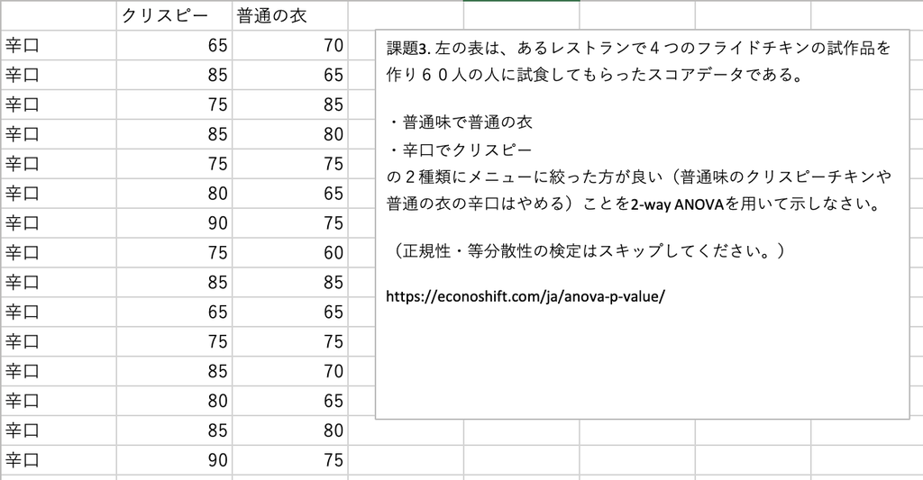

課題3画像

（正規性・等分散性の検定はスキップしてください。）

### データ読み込み

`stringsAsFactors=TRUE`をわすれないように。 データファイルに日本語を含むので`fileEncoding = "utf8"`を追加した。

```r
kadai3 <- read.delim("kadai3.tsv", stringsAsFactors=TRUE,fileEncoding = "utf8")
summary(kadai3)
```

```
##      Aji            Koromo       Score
##  普通味:30   クリスピー:30   Min.   :60.00
##  辛口  :30   普通の衣  :30   1st Qu.:68.75
##                              Median :75.00
##                              Mean   :74.42
##                              3rd Qu.:80.00
##                              Max.   :90.00
```

### 分布の確認

```r
require(Rcmdr)
```

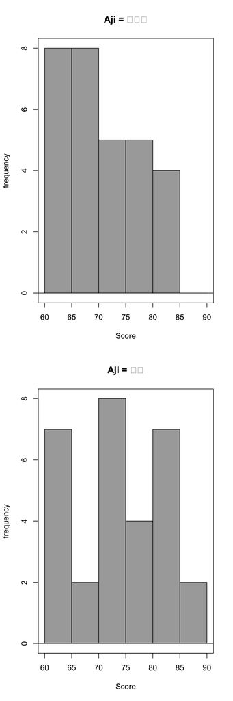

```r
with(kadai3, Hist(Score, groups=Aji, scale="frequency", breaks="Sturges",
  col="darkgray"))
```

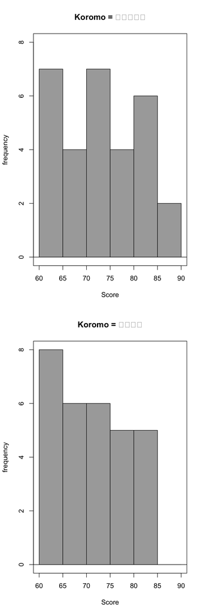

```r
with(kadai3, Hist(Score, groups=Koromo, scale="frequency", breaks="Sturges",
  col="darkgray"))
```

分布を見ても傾向はよくわからない。

### 二元配置分散分析

繰り返しありの二元配置分散分析

- 味（要因A）の主効果
  - 帰無仮説H0: 味の効果がない （FA<F(dfA,dfR,α)）
  - 対立仮説H1: 味の効果がある （FA≥F(dfA,dfR,α)）
- 衣（要因B）の主効果
  - 帰無仮説H0: 衣の効果がない（FB<F(dfB,dfR,α)）
  - 対立仮説H1: 衣の効果がある（FB≥F(dfB,dfR,α)）
- 交互作用
  - 帰無仮説H0: 味と衣の効果に交互作用がない（FA×B<F(dfA×B,dfR,α)）
  - 対立仮説H1: 交互作用がある（FA×B ≥ F(dfA×B,dfR,α)）

```r
summary(aov(Score~Aji*Koromo,data=kadai3))
```

```
##             Df Sum Sq Mean Sq F value Pr(>F)
## Aji          1    184   183.7   3.053 0.0860 .
## Koromo       1     50    50.4   0.838 0.3640
## Aji:Koromo   1    400   400.4   6.654 0.0125 *
## Residuals   56   3370    60.2
## ---
## Signif. codes:  0 '***' 0.001 '**' 0.01 '*' 0.05 '.' 0.1 ' ' 1
```

主要因は有意にならなかったが、交互作用のみが有意となった（p<0.05）。

要因を「展開」してどの味・衣の組合せが異なるかを調べる。

### 多重比較（Tukey-Kramer）

まず、AjiとKoromoをつなげてすべての試験区を区別できる新しい因子AjiKoromoを追加する。

```r
kadai3$AjiKoromo <- as.factor(paste(kadai3$Aji,kadai3$Koromo,sep=""))
summary(kadai3)
```

```
##      Aji            Koromo       Score                  AjiKoromo
##  普通味:30   クリスピー:30   Min.   :60.00   普通味クリスピー:15
##  辛口  :30   普通の衣  :30   1st Qu.:68.75   普通味普通の衣  :15
##                              Median :75.00   辛口クリスピー  :15
##                              Mean   :74.42   辛口普通の衣    :15
##                              3rd Qu.:80.00
##                              Max.   :90.00
```

多重比較にはTukey-Kramerを用いた。

```r
library(multcomp)
result1 <- aov(Score~AjiKoromo,data=kadai3) # 分散分析の結果をresult1に格納
summary(result1) # 結果を表示する
```

```
##             Df Sum Sq Mean Sq F value Pr(>F)
## AjiKoromo    3    635  211.53   3.515 0.0209 *
## Residuals   56   3370   60.18
## ---
## Signif. codes:  0 '***' 0.001 '**' 0.01 '*' 0.05 '.' 0.1 ' ' 1
```

```r
result2 <- glht(result1, linfct = mcp(AjiKoromo = "Tukey")) # Tukey-Kramerの結果をresult2に格納
summary(result2) # 結果を表示する
```

```
##
##   Simultaneous Tests for General Linear Hypotheses
##
## Multiple Comparisons of Means: Tukey Contrasts
##
##
## Fit: aov(formula = Score ~ AjiKoromo, data = kadai3)
##
## Linear Hypotheses:
##                                        Estimate Std. Error t value Pr(>|t|)
## 普通味普通の衣 - 普通味クリスピー == 0    3.333      2.833   1.177   0.6439
## 辛口クリスピー - 普通味クリスピー == 0    8.667      2.833   3.060   0.0176 *
## 辛口普通の衣 - 普通味クリスピー == 0      1.667      2.833   0.588   0.9352
## 辛口クリスピー - 普通味普通の衣 == 0      5.333      2.833   1.883   0.2472
## 辛口普通の衣 - 普通味普通の衣 == 0       -1.667      2.833  -0.588   0.9352
## 辛口普通の衣 - 辛口クリスピー == 0       -7.000      2.833  -2.471   0.0759 .
## ---
## Signif. codes:  0 '***' 0.001 '**' 0.01 '*' 0.05 '.' 0.1 ' ' 1
## (Adjusted p values reported -- single-step method)
```

```r
cld(result2) # compact letter displayで多重比較の結果を表示
```

```
## 普通味クリスピー   普通味普通の衣   辛口クリスピー     辛口普通の衣
##              "a"             "ab"              "b"             "ab"
```

```r
par()$mar # 上が切れるのでマージンを確認（私の場合は5.1 4.1 4.1 2.1）
```

```
## [1] 5.1 4.1 4.1 2.1
```

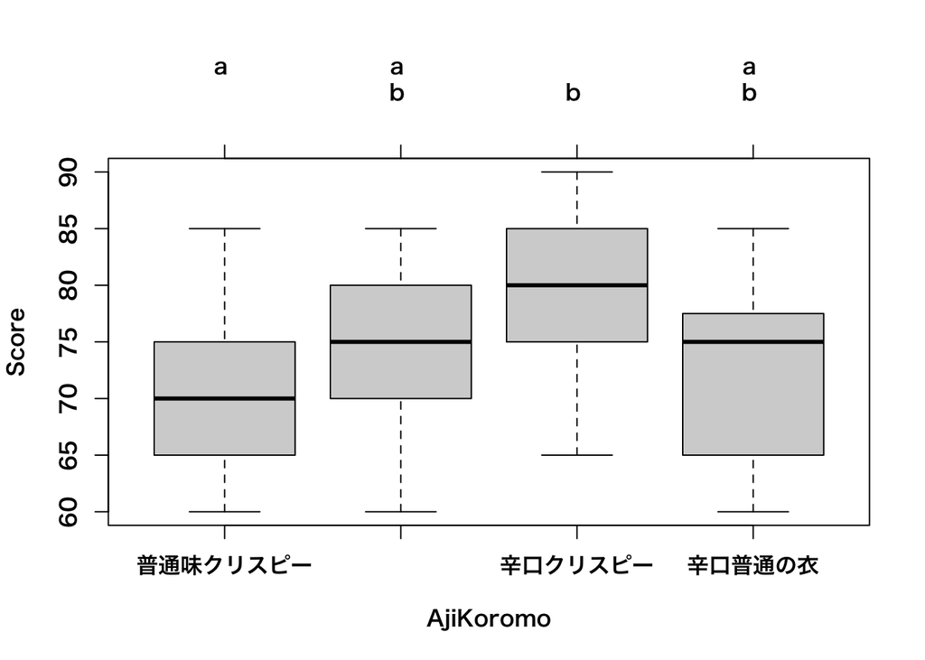

```r
par(mar=c(5.1, 4.1, 6, 2.1)) # 上のマージンを広げる
# 以下のどちらかの行の#を消してチャレンジ 今はMacむけ
# Mac
par(family = "HiraKakuProN-W6") #グラフで日本語を使うおまじないMac
# Windows
#par(family = "Meiryo") #グラフで日本語を使うおまじないWindows
plot(cld(result2)) # compact letter displayつきの箱ひげ図を描く
```

（異なる文字のグループの間では5%水準で有意な差があることを示す。）

## 課題3(2) （課題3よりもありえそうな例）

Repeated measures one-way ANOVA

この表は、あるレストランで４つのフライドチキンの試作品を作り**15人**の人に4種類を試食してもらったスコアデータである。

どの味衣（`AjiKoromo`）の組合せがベストかをANOVAを用いて示しなさい。

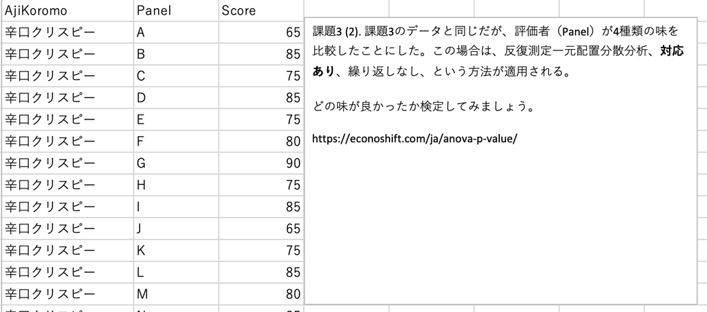

課題3(2)画像

（正規性・等分散性の検定はスキップしてください。）

### データ読み込み

`stringsAsFactors=TRUE`をわすれないように。 データファイルに日本語を含むので`fileEncoding = "utf8"`を追加した。

```r
kadai3_2 <- read.delim("kadai3_2.tsv", stringsAsFactors=TRUE,fileEncoding = "utf8")
summary(kadai3_2)
```

```
##             AjiKoromo      Panel        Score
##  普通味クリスピー:15   A      : 4   Min.   :60.00
##  普通味普通の衣  :15   B      : 4   1st Qu.:68.75
##  辛口クリスピー  :15   C      : 4   Median :75.00
##  辛口普通の衣    :15   D      : 4   Mean   :74.42
##                        E      : 4   3rd Qu.:80.00
##                        F      : 4   Max.   :90.00
##                        (Other):36
```

### 分布の確認

（省略：課題3と同じ）

### 二元配置分散分析

繰り返し測定の一元配置分散分析

- AjiKoromo味衣（要因A）の主効果
  - 帰無仮説H0: AjiKoromoの効果がない （FA<F(dfA,dfR,α)）
  - 対立仮説H1: AjiKoromoの効果がある （FA≥F(dfA,dfR,α)）
- Panelパネル=評価者（要因B）の主効果
  - 帰無仮説H0: 評価者の効果がない（FB<F(dfB,dfR,α)）
  - 対立仮説H1: 評価者の効果がある（FB≥F(dfB,dfR,α)）
- 交互作用 検定できない

```r
summary(aov(Score~AjiKoromo+Panel,data=kadai3_2))
```

```
##             Df Sum Sq Mean Sq F value   Pr(>F)
## AjiKoromo    3  634.6  211.53   6.659 0.000884 ***
## Panel       14 2035.8  145.42   4.578 6.15e-05 ***
## Residuals   42 1334.2   31.77
## ---
## Signif. codes:  0 '***' 0.001 '**' 0.01 '*' 0.05 '.' 0.1 ' ' 1
```

AjiKoromoはScoreと関連がある（p=0）。 PanelはScoreと関連がある（p=0）。

どの味・衣の組合せが異なるかを調べる。

### 多重比較（Tukey-Kramer）

多重比較にはTukey-Kramerを用いた。

```r
library(multcomp)
result1 <- aov(Score~AjiKoromo+Panel,data=kadai3_2) # 分散分析の結果をresult1に格納
summary(result1) # 結果を表示する
```

```
##             Df Sum Sq Mean Sq F value   Pr(>F)
## AjiKoromo    3  634.6  211.53   6.659 0.000884 ***
## Panel       14 2035.8  145.42   4.578 6.15e-05 ***
## Residuals   42 1334.2   31.77
## ---
## Signif. codes:  0 '***' 0.001 '**' 0.01 '*' 0.05 '.' 0.1 ' ' 1
```

```r
result2 <- glht(result1, linfct = mcp(AjiKoromo = "Tukey")) # Tukey-Kramerの結果をresult2に格納
summary(result2) # 結果を表示する
```

```
##
##   Simultaneous Tests for General Linear Hypotheses
##
## Multiple Comparisons of Means: Tukey Contrasts
##
##
## Fit: aov(formula = Score ~ AjiKoromo + Panel, data = kadai3_2)
##
## Linear Hypotheses:
##                                        Estimate Std. Error t value Pr(>|t|)
## 普通味普通の衣 - 普通味クリスピー == 0    3.333      2.058   1.620  0.37891
## 辛口クリスピー - 普通味クリスピー == 0    8.667      2.058   4.211  < 0.001 ***
## 辛口普通の衣 - 普通味クリスピー == 0      1.667      2.058   0.810  0.84945
## 辛口クリスピー - 普通味普通の衣 == 0      5.333      2.058   2.591  0.06058 .
## 辛口普通の衣 - 普通味普通の衣 == 0       -1.667      2.058  -0.810  0.84945
## 辛口普通の衣 - 辛口クリスピー == 0       -7.000      2.058  -3.401  0.00785 **
## ---
## Signif. codes:  0 '***' 0.001 '**' 0.01 '*' 0.05 '.' 0.1 ' ' 1
## (Adjusted p values reported -- single-step method)
```

```r
cld(result2) # compact letter displayで多重比較の結果を表示
```

```
## 普通味クリスピー   普通味普通の衣   辛口クリスピー     辛口普通の衣
##              "a"             "ab"              "b"              "a"
```

```r
par()$mar # 上が切れるのでマージンを確認（私の場合は5.1 4.1 4.1 2.1）
```

```
## [1] 5.1 4.1 4.1 2.1
```

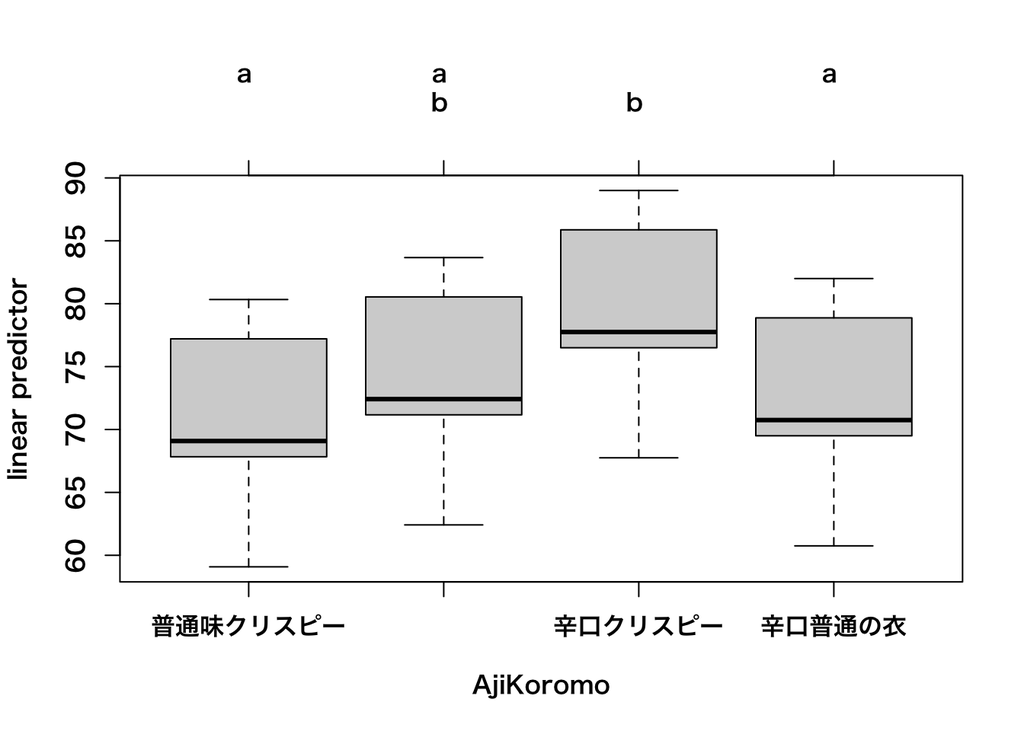

```r
par(mar=c(5.1, 4.1, 6, 2.1)) # 上のマージンを広げる
# 以下のどちらかの行の#を消してチャレンジ 今はMacむけ
# Mac
par(family = "HiraKakuProN-W6") #グラフで日本語を使うおまじないMac
# Windows
#par(family = "Meiryo") #グラフで日本語を使うおまじないWindows
plot(cld(result2)) # compact letter displayつきの箱ひげ図を描く
```

（異なる文字のグループの間では5%水準で有意な差があることを示す。）

課題3とは結果が異なる。検定を方法を間違えると異なる結果を導く可能性がある。

解釈